# Floral biology, pollen viability and stigma receptivity in three species of Casuarina - ScienceDirect

## Figures (6)

[figure not shown]

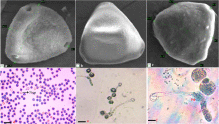

[figure not shown]

## [South African Journal of Botany](https://www.sciencedirect.com/journal/south-african-journal-of-botany)

[Volume 152](https://www.sciencedirect.com/journal/south-african-journal-of-botany/vol/152/suppl/C), January 2023, Pages 182-191

# Floral biology, pollen viability and stigma receptivity in three species of *Casuarina*

https://doi.org/10.1016/j.sajb.2022.11.044[Get rights and content](https://s100.copyright.com/AppDispatchServlet?publisherName=ELS&contentID=S0254629922006329&orderBeanReset=true)

## Highlights

**•**

The pollen viability, storage and germination results showed significant differences among the species of *Casuarina* and between stains (acetocarmine and aniline blue), storage duration, temperature and germination media (BA and BK medium).

**•**

The female flowers had a life span of about 10 days, and the stigma receptivity started 3 days after anthesis and peaked between the fourth and sixth days.

**•**

The receptivity period was linked to distinct morphological characteristics of the stigma, which can be used as a guide for hand pollination.

**•**

Successful storage of pollen and knowledge of the stigma receptivity time help breeders perform controlled pollination, leading to a high level of fruit and seed set.

## Abstract

*Casuarina* species (Casuarinaceae) are nitrogen-fixing multipurpose trees planted extensively throughout the tropics for wood production and environmental services. Increasing productivity of plantations through breeding is underway in China, India and Thailand. The current focus of breeding is to produce interspecific hybrids possessing a combination of specifies-specific characters of forestry importance. Earlier hybridization attempts were less successful mainly due to insufficient knowledge on floral and pollen biologyand lack of efficient hand pollination techniques. The differences in the floral characters and their influence on pollen and seed output in three *Casuarina* species (*C. equisetifolia, C. junghuhniana* and *C. cristata*) were studied. Pollen from six clones were stored at three temperature levels and tested for viability from 3 to 45 days after storage using acetocarmine and aniline blue stains. *In vitro* germination of stored pollen was testedwith two germination media from 3 to 30 days. Female flowers were control pollinated from 1 to 7 days after anthesis and stigma receptivity was determined based on presence of germinating pollen. There was a significant effect of clone, stain, storage temperature and storage period on the viability of pollen. Pollen viability and *in vitro* germination reduced drastically when stored at room temperature for three days but was high under low temperature storage. While the viability of pollen stored at 4°C and -20 °C comparable up to 15 days of storage, freezer storage showed better viability at 45 days. *In vitro* germination was higher with the broad-based Brewbaker-Kwack medium than the basic sucrose-boron medium. The stigma was receptive from the third to seven days after anthesis and the peak period was on fourth and fifth days for *C. equisetifolia* and *C. junghuhniana* and fifth and sixth days for *C. cristata*. The receptivity level of the stigma was associated with distinct morphological features during lifespan of the female flower. Pollen stored under low temperatures can be used to cross parents with dissimilar flowering phenology within the same flowering season and conducting hand pollination during when the stigma is at its peak receptivity will increase hybridization success.

## Keywords

Casuarina

Breeding

Hybridization

Control pollination

Pollen germination

Pollen storage

Stigma receptivity

## Cited by (0)

[View full text](https://www.sciencedirect.com/science/article/pii/S0254629922006329)

© 2022 SAAB. Published by Elsevier B.V. All rights reserved.

  Moupriya Mondal, Indrani Chandra

  Xuehui Xu, …, Yuexin Zhang

  Marileide Dias Saba, Francisco de Assis Ribeiro dos Santos